# Exercises of Models Course

## Generalized Linear models

### Exercise 1

A researcher is interested in how variables, such as GRE (Graduate Record Exam scores), GPA (grade point average) and prestige of the undergraduate institution, effect admission into graduate school. The response variable, admit/don’t admit, is a binary variable.

```r
data(admission)
head(admission)
```

```
## Source: local data frame [6 x 4]
##
##   admit   gre   gpa  rank
##   (int) (int) (dbl) (int)
## 1     0   380  3.61     3
## 2     1   660  3.67     3
## 3     1   800  4.00     1
## 4     1   640  3.19     4
## 5     0   520  2.93     4
## 6     1   760  3.00     2
```

This dataset has a binary response (outcome, dependent) variable called `admit`. There are three predictor variables: `gre`, `gpa` and `rank`. We will treat the variables `gre` and `gpa` as continuous. The variable `rank` takes on the values 1 through 4. Institutions with a rank of 1 have the highest prestige, while those with a rank of 4 have the lowest.

1. Let us compute the descriptive statistics for all variables. Let us produce the plots showing the relation between `admit` and `GPA` by `rank`, with lowess lines and the plots showing the relation between `admit` and `GRE` by `rank`, with lowess lines.

```r
# Descriptive Statistics
summary(admission)
```

```
##      admit             gre             gpa             rank
##  Min.   :0.0000   Min.   :220.0   Min.   :2.260   Min.   :1.000
##  1st Qu.:0.0000   1st Qu.:520.0   1st Qu.:3.130   1st Qu.:2.000
##  Median :0.0000   Median :580.0   Median :3.395   Median :2.000
##  Mean   :0.3175   Mean   :587.7   Mean   :3.390   Mean   :2.485
##  3rd Qu.:1.0000   3rd Qu.:660.0   3rd Qu.:3.670   3rd Qu.:3.000
##  Max.   :1.0000   Max.   :800.0   Max.   :4.000   Max.   :4.000
```

```r
admission %>% summarise_each(funs="sd")
```

```
## Source: local data frame [1 x 4]
##
##       admit      gre       gpa      rank
##       (dbl)    (dbl)     (dbl)     (dbl)
## 1 0.4660867 115.5165 0.3805668 0.9444602
```

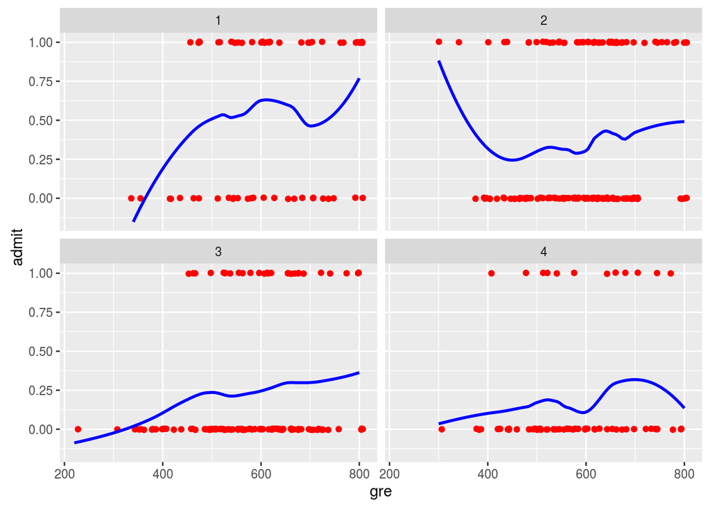

```r
# Graphs of admit and GRE by rank
ggp1 <- ggplot(data = admission, mapping = aes(x = gre, y= admit)) +
  geom_jitter(mapping = aes(y=admit), colour="red", height = 0.01) +
  geom_smooth(method = "loess", colour="blue", se = FALSE, span=2/3) +
  facet_wrap(facets = ~rank)
print(ggp1)
```

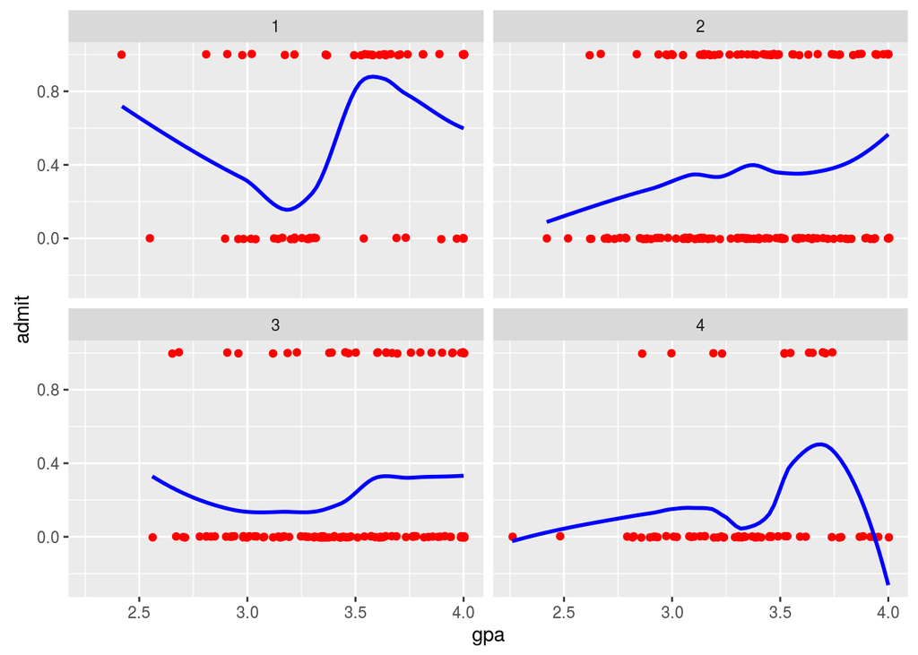

```r
# Graphs of admit and GPA by rank
ggp2 <- ggplot(data = admission, mapping = aes(x = gpa, y= admit)) +
  geom_jitter(mapping = aes(y=admit), colour="red", height = 0.01) +
  geom_smooth(method = "loess", colour="blue", se = FALSE, span=2/3) +
  facet_wrap(facets = ~rank)
print(ggp2)
```

2. Let us estimate a logistic regression model using the `glm` (generalized linear model) function. First, we convert `rank` to a factor to indicate that `rank` should be treated as a categorical variable.

```r
admission <- admission %>% mutate(rank=factor(rank))
fm1 <- glm(admit ~ gre + gpa + rank, data = admission, family = "binomial")
summary(fm1)
```

```
##
## Call:
## glm(formula = admit ~ gre + gpa + rank, family = "binomial",
##     data = admission)
##
## Deviance Residuals:
##     Min       1Q   Median       3Q      Max
## -1.6268  -0.8662  -0.6388   1.1490   2.0790
##
## Coefficients:
##              Estimate Std. Error z value Pr(>|z|)
## (Intercept) -3.989979   1.139951  -3.500 0.000465 ***
## gre          0.002264   0.001094   2.070 0.038465 *
## gpa          0.804038   0.331819   2.423 0.015388 *
## rank2       -0.675443   0.316490  -2.134 0.032829 *
## rank3       -1.340204   0.345306  -3.881 0.000104 ***
## rank4       -1.551464   0.417832  -3.713 0.000205 ***
## ---
## Signif. codes:  0 '***' 0.001 '**' 0.01 '*' 0.05 '.' 0.1 ' ' 1
##
## (Dispersion parameter for binomial family taken to be 1)
##
##     Null deviance: 499.98  on 399  degrees of freedom
## Residual deviance: 458.52  on 394  degrees of freedom
## AIC: 470.52
##
## Number of Fisher Scoring iterations: 4
```

```r
# For every one unit change in gre, the log odds of admission (versus non-admission) increases by 0.002
# For a one unit increase in gpa, the log odds of being admitted to graduate school increases by 0.804.
# The indicator variables for rank have a slightly different interpretation. For example, having attended an undergraduate institution with rank of 2, versus an institution with a rank of 1, changes the log odds of admission by -0.675.
```

3. Check the model residuals.

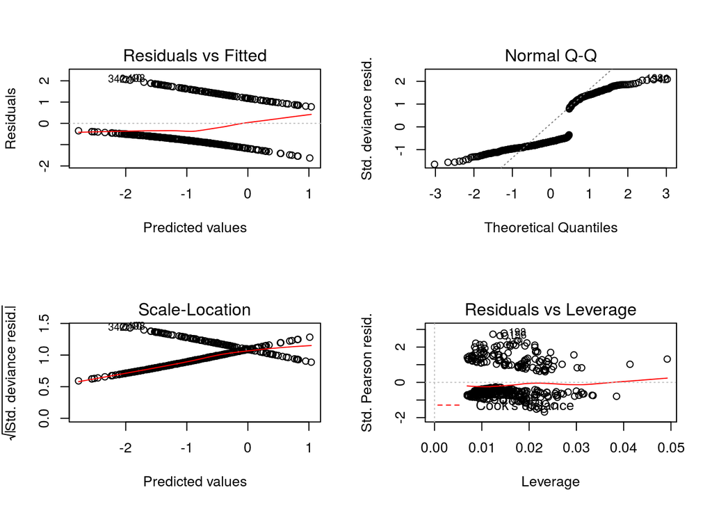

```r
op <- par(mfrow = c(2,2))
plot(fm1)
```

```r
par(op)
# The diagnostic graphs are not really nice, but similar configurations of points is not infrequent, when the response variable is a Bernoulli (not Binomial) one.
```

4. Let us compute model predictions.

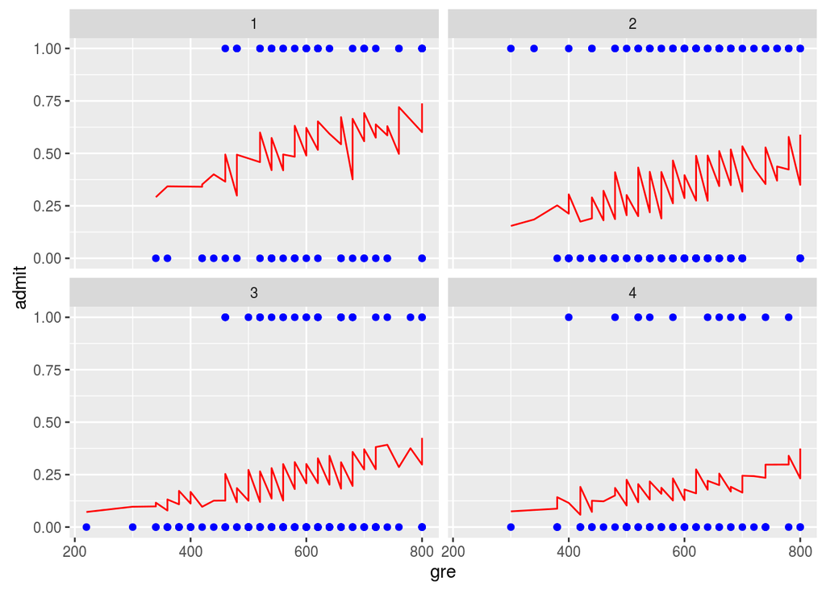

```r
admission$prob <- predict(fm1, type = "response")
admission <- admission %>% arrange(prob)

# Prediction of admit vs gre by rank
ggp <- ggplot(data = admission, mapping = aes(x = gre, y = admit)) +
  geom_point(colour="blue") +
  geom_line(mapping = aes(x = gre, y = prob), colour="red") +
  facet_wrap(facets = ~rank)
print(ggp)
```

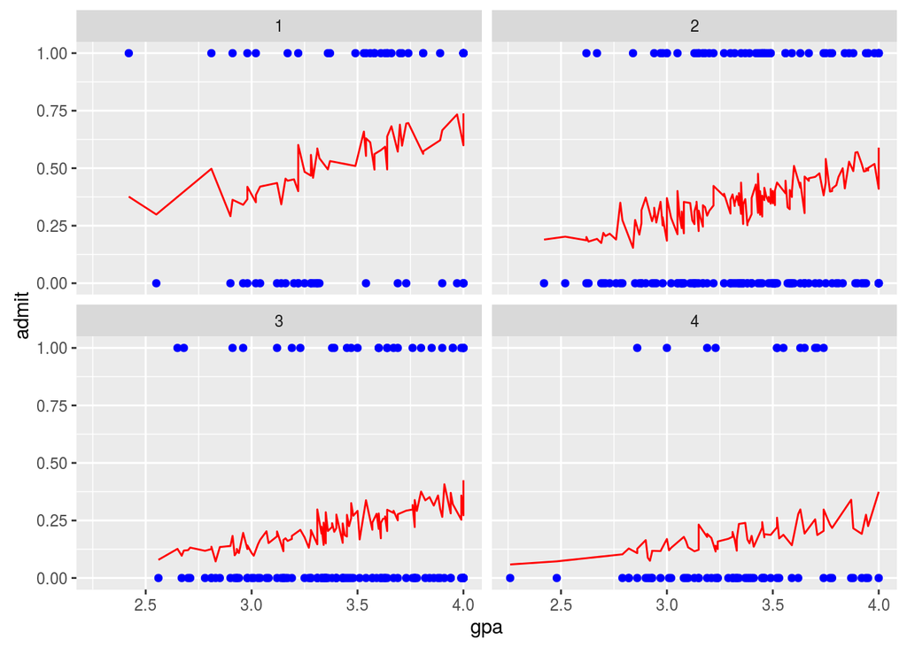

```r
# Prediction of admit vs gpa by rank
ggp <- ggplot(data = admission, mapping = aes(x = gpa, y = admit)) +
  geom_point(colour="blue") +
  geom_line(mapping = aes(x = gpa, y = prob), colour="red") +
  facet_wrap(facets = ~rank)
print(ggp)
```

### Exercise 2

We want to analyze if the number of awards earned by students at one high school are related to the type of program in which the student was enrolled (e.g., vocational, general or academic) and to the score on their final exam in math.

```r
data(awards)
head(awards)
```

```
## Source: local data frame [6 x 4]
##
##      id num_awards  prog  math
##   (int)      (int) (int) (int)
## 1    45          0     3    41
## 2   108          0     1    41
## 3    15          0     3    44
## 4    67          0     3    42
## 5   153          0     3    40
## 6    51          0     1    42
```

```r
# Convert prog and id variables as factors
awards <- awards %>% mutate(prog=factor(prog, levels=1:3, labels=c("General", "Academic", "Vocational")),
            id = factor(id))
```

`num_awards` is the outcome variable and indicates the number of awards earned by students at a high school in a year, `math` is a continuous predictor variable and represents students’ scores on their math final exam, and `prog` is a categorical predictor variable with three levels indicating the type of program in which the students were enrolled. It is coded as 1 = “General”, 2 = “Academic” and 3 = “Vocational”.

1. Let us compute some descriptive statistics of all variables and generate an histogram of the number of awards earned by students by program type.

```r
# Descriptive Statistics
summary(awards)
```

```
##        id        num_awards           prog          math
##  1      :  1   Min.   :0.00   General   : 45   Min.   :33.00
##  2      :  1   1st Qu.:0.00   Academic  :105   1st Qu.:45.00
##  3      :  1   Median :0.00   Vocational: 50   Median :52.00
##  4      :  1   Mean   :0.63                    Mean   :52.65
##  5      :  1   3rd Qu.:1.00                    3rd Qu.:59.00
##  6      :  1   Max.   :6.00                    Max.   :75.00
##  (Other):194
```

```r
awards %>% summarise_each(funs(sd))
```

```
## Source: local data frame [1 x 4]
##
##         id num_awards      prog     math
##      (dbl)      (dbl)     (dbl)    (dbl)
## 1 57.87918   1.052921 0.6904772 9.368448
```

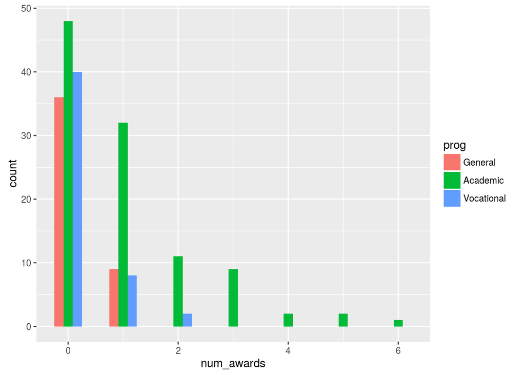

```r
# Histogram
ggp <- ggplot(awards, aes(num_awards, fill = prog)) +
  geom_histogram(binwidth=.5, position="dodge")
ggp
```

2. Let us perform a Poisson model analysis using the `glm` function, considering the complete (additive) model.

```r
fm1 <- glm(num_awards ~ prog + math, family="poisson", data=awards)
summary(fm1)
```

```
##
## Call:
## glm(formula = num_awards ~ prog + math, family = "poisson", data = awards)
##
## Deviance Residuals:
##     Min       1Q   Median       3Q      Max
## -2.2043  -0.8436  -0.5106   0.2558   2.6796
##
## Coefficients:
##                Estimate Std. Error z value Pr(>|z|)
## (Intercept)    -5.24712    0.65845  -7.969 1.60e-15 ***
## progAcademic    1.08386    0.35825   3.025  0.00248 **
## progVocational  0.36981    0.44107   0.838  0.40179
## math            0.07015    0.01060   6.619 3.63e-11 ***
## ---
## Signif. codes:  0 '***' 0.001 '**' 0.01 '*' 0.05 '.' 0.1 ' ' 1
##
## (Dispersion parameter for poisson family taken to be 1)
##
##     Null deviance: 287.67  on 199  degrees of freedom
## Residual deviance: 189.45  on 196  degrees of freedom
## AIC: 373.5
##
## Number of Fisher Scoring iterations: 6
```

```r
#  The coefficient for math is .07. This means that the expected log count for a one-unit increase in math is .07. The indicator variable progAcademic compares between prog = "Academic" and prog = "General", the expected log count for prog = "Academic" increases by about 1.1. The indicator variable prog.Vocational is the expected difference in log count (approx .37) between prog = "Vocational" and the reference group (prog = "General").
```

3. Let us try to improve the model removing non significant variable/s. Compares this model with the previous one.

```r
## update m1 model dropping prog
fm2 <- update(fm1, . ~ . - prog)
summary(fm2)
```

```
##
## Call:
## glm(formula = num_awards ~ math, family = "poisson", data = awards)
##
## Deviance Residuals:
##     Min       1Q   Median       3Q      Max
## -2.1853  -0.9070  -0.6001   0.3246   2.9529
##
## Coefficients:
##              Estimate Std. Error z value Pr(>|z|)
## (Intercept) -5.333532   0.591261  -9.021   <2e-16 ***
## math         0.086166   0.009679   8.902   <2e-16 ***
## ---
## Signif. codes:  0 '***' 0.001 '**' 0.01 '*' 0.05 '.' 0.1 ' ' 1
##
## (Dispersion parameter for poisson family taken to be 1)
##
##     Null deviance: 287.67  on 199  degrees of freedom
## Residual deviance: 204.02  on 198  degrees of freedom
## AIC: 384.08
##
## Number of Fisher Scoring iterations: 6
```

```r
## test model differences with chi square test
anova(fm2, fm1, test="Chisq")
```

```
## Analysis of Deviance Table
##
## Model 1: num_awards ~ math
## Model 2: num_awards ~ prog + math
##   Resid. Df Resid. Dev Df Deviance  Pr(>Chi)
## 1       198     204.02
## 2       196     189.45  2   14.572 0.0006852 ***
## ---
## Signif. codes:  0 '***' 0.001 '**' 0.01 '*' 0.05 '.' 0.1 ' ' 1
```

```r
# The best model is the complete model (first)
```

4. Let us compure predictions of the best fitted model.

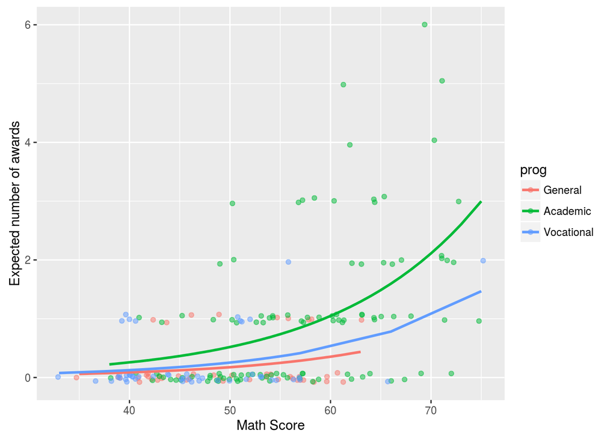

```r
## calculate and store predicted values
awards$phat <- predict(fm1, type="response")

## order by program and then by math
awards <- awards %>% arrange(prog, math)

## create the plot
ggp <- ggplot(awards, aes(x = math, y = phat, colour = prog)) +
  geom_point(aes(y = num_awards), alpha=.5, position=position_jitter(h=.2)) +
  geom_line(size = 1) +
  labs(x = "Math Score", y = "Expected number of awards")
print(ggp)
```